# PS Adjusted PheWAS

RobertJCarroll

September 26, 2017

# Set up environment

Our first step will be to install and load the proper libraries as necessary.

# Set up data

## Load the data

Next, we need to create some sample data; this may take a moment. It’s also possible to load in the existing data from the [PheWASExamples github repo](https://github.com/PheWAS/PheWASExamples). If you have downloaded that repo, one can use the “load_data” block instead.

The demographic data looks like this:

```r
demo %>% group_by(exposed) %>% summarize(N=n(),
  `N Female (%)`=sprintf("%d (%.1f%%)",sum(is.female),100*sum(is.female)/N),
  `Age (SD)`=sprintf("%.1f (%.1f)",mean(current.age),sd(current.age)),
  `N White (%)`=sprintf("%d (%.1f%%)",sum(is.white),100*sum(is.white)/N)
)
```

```
## # A tibble: 2 x 5
##   exposed     N `N Female (%)` `Age (SD)` `N White (%)`
##   <lgl>   <int> <chr>          <chr>      <chr>
## 1 F        9000 4502 (50.0%)   11.1 (3.5) 3238 (36.0%)
## 2 T        1000 483 (48.3%)    10.9 (3.5) 346 (34.6%)
```

## Normalize age

We need to normalize our age values for use in the PS creation.

```r
processed.demo = demo %>% mutate(current.age = (current.age - mean(demo$current.age))/sd(demo$current.age))
```

## Prepare phecodes

We need to map our ICD9CM codes to phecodes for PheWAS. Because of the short time windows and importance of catching all events, we will be using a minimum code count of 1. We are also not using exclusions for this analysis- especially important for the baseline as the missingness makes propensity score generation harder.

```r
baseline.phecodes = createPhewasTable(baseline.icd, min.code.count = 1, add.exclusions = FALSE)
```

```
## Mapping ICD-9 codes to phecodes...
```

```
## Aggregating codes...
```

```
## Coalescing exclusions and min.code.count as applicable...
```

```
## Reshaping data...
```

```r
outcome.phecodes = createPhewasTable(outcome.icd, min.code.count = 1, add.exclusions = FALSE)
```

```
## Mapping ICD-9 codes to phecodes...
```

```
## Aggregating codes...
```

```
## Coalescing exclusions and min.code.count as applicable...
```

```
## Reshaping data...
```

Note that if one has individuals with no phecodes, eg, they only had well child ICD9CM codes, those records may be missing from the phecodes objects. One could use a left_join and replace the resulting NAs below to avoid those troubles.

## Merge data

Combining our data into “baseline” and “outcome” data frames will allow us to build the PS and run the PheWAS, respectively. For an idea of our data frame, we’ll print out the first 10 rows and columns.

```r
baseline.data = inner_join(processed.demo,baseline.phecodes,by="id")
outcome.data = inner_join(processed.demo,outcome.phecodes,by="id")
baseline.data[1:10,1:10]
```

```
##    id current.age is.female is.white exposed   008 008.5 008.51 008.52
## 1   1   1.2028695      TRUE    FALSE    TRUE FALSE FALSE  FALSE  FALSE
## 2   2  -1.0296032     FALSE    FALSE    TRUE FALSE FALSE  FALSE  FALSE
## 3   3   0.1053572     FALSE    FALSE    TRUE FALSE FALSE  FALSE  FALSE
## 4   4   0.0304613      TRUE     TRUE    TRUE FALSE FALSE  FALSE  FALSE
## 5   5  -0.1106886      TRUE    FALSE    TRUE FALSE FALSE  FALSE  FALSE
## 6   6  -1.0238419     FALSE    FALSE    TRUE FALSE FALSE  FALSE  FALSE
## 7   7  -1.5797997     FALSE     TRUE    TRUE FALSE FALSE  FALSE  FALSE
## 8   8   1.5456621      TRUE    FALSE    TRUE FALSE FALSE  FALSE  FALSE
## 9   9  -1.0872154     FALSE     TRUE    TRUE FALSE FALSE  FALSE  FALSE
## 10 10  -0.9979165      TRUE    FALSE    TRUE FALSE FALSE  FALSE  FALSE
##    008.6
## 1  FALSE
## 2  FALSE
## 3  FALSE
## 4  FALSE
## 5  FALSE
## 6  FALSE
## 7  FALSE
## 8  FALSE
## 9  FALSE
## 10 FALSE
```

## Clean up

We can remove some of these left over objects after we have done any exploration we’d like to do.

```r
rm(baseline.icd,baseline.phecodes,outcome.icd,outcome.phecodes,processed.demo)
```

# Pre-process data

## Prepare outcome data

### Select viable outcome phenotypes

We are going to remove phenotypes from our outcome data frame that have zero or one case. First, create the counts in each column, then select only those with at least two cases.

```r
all.phenotypes <- colSums(outcome.data %>% select(-one_of(names(demo))),na.rm = T)
outcome.phenotypes <- names(all.phenotypes[all.phenotypes>1])
rm(all.phenotypes)
```

### Select only those columns

```r
outcome.data = outcome.data %>% select(one_of(c(names(demo),outcome.phenotypes)))
```

## Prepare baseline data

### Select helpful baseline phenotypes

We need to select 3 digit phecodes with at least one case.

```r
#Select only sums for 3 digit phecodes
all.covariate.phenotypes <- colSums(baseline.data %>%
                                      select(-one_of(names(demo))) %>%
                                      select(matches("^[0-9]{3}$")), na.rm = T)

#Remove those with no cases
baseline.phenotypes <- names(all.covariate.phenotypes[all.covariate.phenotypes>0])
rm(all.covariate.phenotypes)
```

### Select only those columns

```r
baseline.data = baseline.data %>% select(one_of(c(names(demo),baseline.phenotypes)))
```

# Create Propensity Score

## Parameters

We’ll be setting the random seed so we can replicate aany results. In addition, we are choosing an alpha of 0.1, which balances the penalty more towards the ridge regression.

```r
set.seed(10)
alpha.para <- 0.1
#Get all but the ID amd exposure status for the baseline data
data.x <- as.matrix(baseline.data %>% select(-id, -exposed))
```

## Fit the penalized regression model

Next, we generate the model using the glmnet package.

```r
glmnet.fit <- cv.glmnet(x=data.x, y=baseline.data$exposed, family="binomial", standardize=TRUE, alpha=alpha.para)
```

## Generate Propensity Score

We’ll finally create the propensity score using our cross validated fit. We are picking the minimum lambda value from the CV.

```r
ps <- predict(glmnet.fit, data.x, s='lambda.min')[,"1"]
data.ps <- data.frame(id=baseline.data$id, PS=ps)
outcome.data <- inner_join(data.ps, outcome.data, by='id')
```

# Perform PheWAS

## Run analysis

We are now ready to run our PheWAS. Supplying our identified phenotypes and exposure status, we will adjust by the generated propensity score. Note that this is set to use four cores by default, but more will speed things up. The logistf package is used for the actual regression models- it can be fairly computationally intensive.

```r
results=phewas_ext(
  #The outcomes for our association analysis
  phenotypes=outcome.phenotypes,
  #Our predictor of interest
  predictors="exposed",
  #Our covariate for adjusting our models
  covariates="PS",
  #Input data frame
  data=outcome.data,
  #We aren't using genotype data, so skip Hardy-Weinberg calculations.
  additive.genotypes=F,
  #Use thePML / Firth Regression
  method="logistf",
  #We've already done our filtering above for the minimum number of cases.
  min.records=0,
  #Use parallel to run on 4 cores
  cores = 4)
```

```
## Starting cluster...
```

```
## Cluster created, finding associations...
```

```
## Compiling results...
```

```
## Cleaning up...
```

## Filter phenotypes

We are doing some post-hoc filtering of congenital anomalies based on phecode groupings and names. We also could have done this ahead of time to save us the computational power

```r
#Using the pheinfo table from PheWAS, find those that meet our non-congenital criteria
non_congenital_list = PheWAS::pheinfo %>% filter(group!='congenital anomalies',!grepl("congenital",description,ignore.case=T))

filtered.results = results %>%
  #Filter out congenital conditions
  filter(phenotype %in% non_congenital_list$phecode) %>%
  #Sort by p-value
  arrange(p)
```

## Plot Results

Let’s take a graphical look at what we found.

```r
result.plot=phewasManhattan(
  #Our filtered results
  filtered.results,
  #Annotate anything with p<0.001
  annotate.level=1e-3,
  title="PheWAS on Drug Exposure, PS Adjusted",
  #Add more marks on the y axis
  y.axis.interval=1,
  #Shape the plots according to effect direction
  OR.direction=T
  )
```

```
## which will replace the existing scale.
```

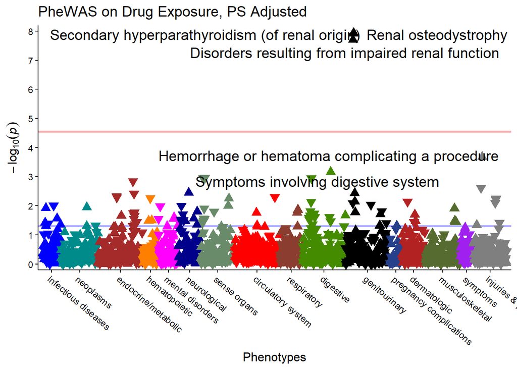

```r
result.plot
```

## Show results We can also show results in a nice looking datatable.

```r
phewasDT(filtered.results %>% mutate(snp=predictor))
```

| phenotype | description | snp | OR | p | n_total | n_cases | n_controls |
| --- | --- | --- | --- | --- | --- | --- | --- |
| 588.2 | Secondary hyperparathyroidism (of renal origin) | exposedTRUE | 1.47 | 1.15e-08 | 10000 | 3626 | 6374 |
| 588.1 | Renal osteodystrophy | exposedTRUE | 1.47 | 1.19e-08 | 10000 | 3616 | 6384 |
| 588 | Disorders resulting from impaired renal function | exposedTRUE | 1.47 | 1.92e-08 | 10000 | 3648 | 6352 |
| 850 | Hemorrhage or hematoma complicating a procedure | exposedTRUE | 3.67 | 0.000208 | 10000 | 49 | 9951 |
| 561 | Symptoms involving digestive system | exposedTRUE | 3.18 | 0.000686 | 10000 | 56 | 9944 |
| 362.29 | Macular degeneration (senile) of retina NOS | exposedTRUE | 0.28 | 0.0011 | 10000 | 148 | 9852 |
| 527.8 | Other specified diseases of the salivary glands | exposedTRUE | 0.2 | 0.00112 | 10000 | 112 | 9888 |
| 362.2 | Degeneration of macula and posterior pole of retina | exposedTRUE | 0.52 | 0.00114 | 10000 | 408 | 9592 |
| 275.3 | Disorders of magnesium metabolism | exposedTRUE | 0.21 | 0.00144 | 10000 | 103 | 9897 |
| 840.1 | Muscle/tendon sprain | exposedTRUE | 0.22 | 0.0024 | 10000 | 103 | 9897 |

[output cut: 1739 more lines]